# Assignment 3

Name : Ibtesam Shaikh

Student ID: 100812266

**Assignment 3:**  
**Neural Networks**

**TO-DO:**

1. a. Using Python generate the **Neural Network** Algorithm. Note: All steps need to be annotated (i.e. header notes for each step).  
   Attach a separate HTML copy of your Python Code with your submission
2. Summary of key findings based on your Python Script:  
   a. State and Explain the Key Statistics of the Dataset (i.e. Mean, Std Deviation, etc.)  
   b. State and Explain the final Algorithm  
   c. Evaluate the Algorithm (i.e. Do you think it’s a good model? Why/Why Not?)
3. Next Steps  
   a. Identify three (3) ways to help improve the performance of the model? Please justify each of your answers.

**Dataset:**

The variables are as follows:  
**Independent Variables:**  
• id: id number  
• Clump Thickness: 1 - 10  
• Uniformity of Cell Size: 1 - 10  
• Uniformity of Cell Shape: 1 - 10  
• Marginal Adhesion: 1 - 10  
• Single Epithelial Cell Size: 1 - 10  
• Bare Nuclei: 1 - 10  
• Bland Chromatin: 1 - 10  
• Normal Nucleoli: 1 - 10  
• Mitoses: 1 - 10  
**Dependent Variable:**  
• Class: (2 for benign, 4 for malignant)

**Theory:**

### Neural Network

Modeled in accordance with the human brain, a Neural Network was built to mimic the functionality of a human brain.  
The human brain is a neural network made up of multiple neurons, similarly, an Artificial Neural Network (ANN) is made up of multiple perceptrons  
**Preceptron:**  
A perceptron works by taking in some numerical inputs along with what is known as weights and a bias  
. It then multiplies these inputs with the respective weights(this is known as the weighted sum).  
These products are then added together along with the bias.  
The activation function takes the weighted sum and the bias as inputs and returns a final output.

[figure not shown]

**Multi Layer Preceptron:**  
A multilayer perceptron (MLP) is a deep, artificial neural network. It is composed of more than one perceptron.  
They are composed of an input layer to receive the signal, an output layer that makes a decision or prediction about the input, and in between those two,  
an arbitrary number of hidden layers that are the true computational engine of the MLP.  
MLPs with one hidden layer are capable of approximating any continuous function.

[figure not shown]

The input layer sends the output to the hidden layer with some weight.  
In the Hidden layer , the weight is summed with the bias(threshold) and sent into the activation function.  
if the output is higher than the threshold value, then the output is sent to the next layer.

# Import all the required Packages :

```python
import pandas as pd
import numpy as np
import matplotlib.pyplot as plt
%matplotlib inline
import seaborn as sns
from sklearn.preprocessing import StandardScaler
from sklearn.model_selection import train_test_split
from sklearn.metrics import classification_report, confusion_matrix
from sklearn.metrics import accuracy_score
from sklearn.neural_network import MLPClassifier
from sklearn.linear_model import LogisticRegression
```

### Read the CSV File in python:

```python
df=pd.read_csv("cancer.csv")
df
```

|  | id | Clump Thickness | UofCSize | UofCShape | Marginal Adhesion | SECSize | Bare Nuclei | Bland Chromatin | Normal Nucleoli | Mitoses | Class |
| --- | --- | --- | --- | --- | --- | --- | --- | --- | --- | --- | --- |
| 0 | 1000025 | 5 | 1 | 1 | 1 | 2 | 1 | 3 | 1 | 1 | 2 |
| 1 | 1002945 | 5 | 4 | 4 | 5 | 7 | 10 | 3 | 2 | 1 | 2 |
| 2 | 1015425 | 3 | 1 | 1 | 1 | 2 | 2 | 3 | 1 | 1 | 2 |
| 3 | 1016277 | 6 | 8 | 8 | 1 | 3 | 4 | 3 | 7 | 1 | 2 |
| 4 | 1017023 | 4 | 1 | 1 | 3 | 2 | 1 | 3 | 1 | 1 | 2 |
| ... | ... | ... | ... | ... | ... | ... | ... | ... | ... | ... | ... |
| 678 | 776715 | 3 | 1 | 1 | 1 | 3 | 2 | 1 | 1 | 1 | 2 |
| 679 | 841769 | 2 | 1 | 1 | 1 | 2 | 1 | 1 | 1 | 1 | 2 |
| 680 | 888820 | 5 | 10 | 10 | 3 | 7 | 3 | 8 | 10 | 2 | 4 |
| 681 | 897471 | 4 | 8 | 6 | 4 | 3 | 4 | 10 | 6 | 1 | 4 |
| 682 | 897471 | 4 | 8 | 8 | 5 | 4 | 5 | 10 | 4 | 1 | 4 |

683 rows × 11 columns

### Size of the Dataset:

```python
df.shape
```

```
(683, 11)
```

### Drop the ID Column:

```python
df=df.drop('id',axis=1)
```

### First 5 records:

```python
df.head()
```

|  | Clump Thickness | UofCSize | UofCShape | Marginal Adhesion | SECSize | Bare Nuclei | Bland Chromatin | Normal Nucleoli | Mitoses | Class |
| --- | --- | --- | --- | --- | --- | --- | --- | --- | --- | --- |
| 0 | 5 | 1 | 1 | 1 | 2 | 1 | 3 | 1 | 1 | 2 |
| 1 | 5 | 4 | 4 | 5 | 7 | 10 | 3 | 2 | 1 | 2 |
| 2 | 3 | 1 | 1 | 1 | 2 | 2 | 3 | 1 | 1 | 2 |
| 3 | 6 | 8 | 8 | 1 | 3 | 4 | 3 | 7 | 1 | 2 |
| 4 | 4 | 1 | 1 | 3 | 2 | 1 | 3 | 1 | 1 | 2 |

### DataTypes of the Dataset:

```python
df.dtypes
```

```
Clump Thickness      int64
UofCSize             int64
UofCShape            int64
Marginal Adhesion    int64
SECSize              int64
Bare Nuclei          int64
Bland Chromatin      int64
Normal Nucleoli      int64
Mitoses              int64
Class                int64
dtype: object
```

### Check for Null Values :

```python
df.isnull().sum()
```

```
Clump Thickness      0
UofCSize             0
UofCShape            0
Marginal Adhesion    0
SECSize              0
Bare Nuclei          0
Bland Chromatin      0
Normal Nucleoli      0
Mitoses              0
Class                0
dtype: int64
```

### Check if the Data is Normal :

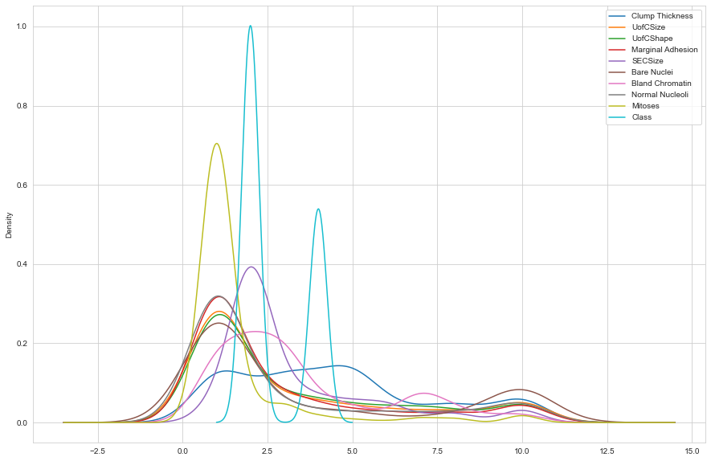

```python
df.plot.kde(figsize=(15,10))
```

### Checking for Outliers Columnwise :

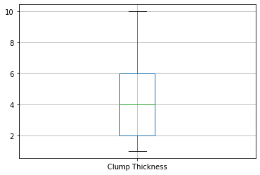

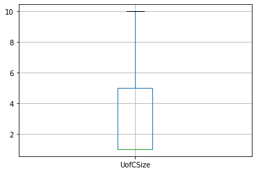

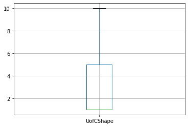

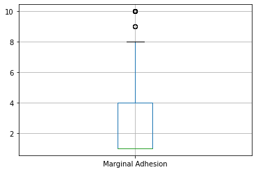

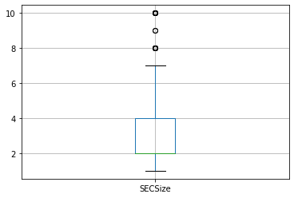

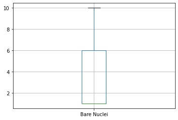

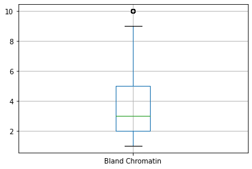

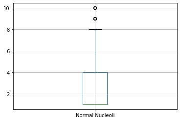

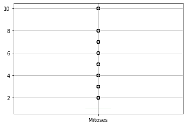

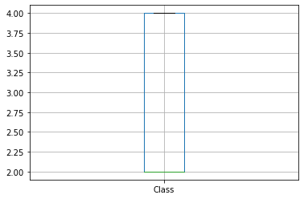

```python
for column in df:
    plt.figure()
    df.boxplot([column])
```

### Key Statistics:

```python
df.describe()
```

|  | Clump Thickness | UofCSize | UofCShape | Marginal Adhesion | SECSize | Bare Nuclei | Bland Chromatin | Normal Nucleoli | Mitoses | Class |
| --- | --- | --- | --- | --- | --- | --- | --- | --- | --- | --- |
| count | 683.000000 | 683.000000 | 683.000000 | 683.000000 | 683.000000 | 683.000000 | 683.000000 | 683.000000 | 683.000000 | 683.000000 |
| mean | 4.442167 | 3.150805 | 3.215227 | 2.830161 | 3.234261 | 3.544656 | 3.445095 | 2.869693 | 1.603221 | 2.699854 |
| std | 2.820761 | 3.065145 | 2.988581 | 2.864562 | 2.223085 | 3.643857 | 2.449697 | 3.052666 | 1.732674 | 0.954592 |
| min | 1.000000 | 1.000000 | 1.000000 | 1.000000 | 1.000000 | 1.000000 | 1.000000 | 1.000000 | 1.000000 | 2.000000 |
| 25% | 2.000000 | 1.000000 | 1.000000 | 1.000000 | 2.000000 | 1.000000 | 2.000000 | 1.000000 | 1.000000 | 2.000000 |
| 50% | 4.000000 | 1.000000 | 1.000000 | 1.000000 | 2.000000 | 1.000000 | 3.000000 | 1.000000 | 1.000000 | 2.000000 |
| 75% | 6.000000 | 5.000000 | 5.000000 | 4.000000 | 4.000000 | 6.000000 | 5.000000 | 4.000000 | 1.000000 | 4.000000 |
| max | 10.000000 | 10.000000 | 10.000000 | 10.000000 | 10.000000 | 10.000000 | 10.000000 | 10.000000 | 10.000000 | 4.000000 |

### Histogram of Class Variable :

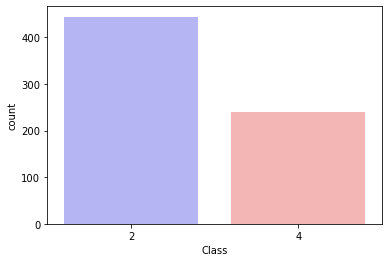

```python
sns.countplot(x="Class", data=df, palette="bwr")
plt.show()
```

# Modelling :

### Logistic Regression Model:

##### Step 1:Create X and Y Variables

**drop()** drops the Class Column from the dataset and assigns all other variables to x. axis=1 Specifies column.

y is assigned Class Varaible .

x is the Independent Variable and y is the dependent variable.

**.to_numpy()** stores the data to an array

##### Step 2: Creating Train and Test Data

**skilearn.model_selection** is the package from which **train_test_split** function is imported.

**test_size** determines the size of the test data set.we are considering 80:20 ratio

**random_state** number splits the train and test datasets with random manner.

##### Step 3: Scaling the Data.

Standardization of the Data is one of the most important step.Standardization comes into picture when features of input data set have large differences between their ranges, or simply when they are measured in different measurement units (e.g., Pounds, Meters, Miles … etc).It is one of the pre-processing step.

StandardScaler is the function used to Standardize the data.It is imported from **sklearn.preprocessing** package.

**fit_transform** is used on the training data. The **fit** method is calculating the mean and variance of each of the features present in our data. The **transform** method is transforming all the features using the respective mean and variance and transforms the data in one format.

**transform** is used on the testng data.Using the **transform** method we can use the same mean and variance as it is calculated from our training data to transform our test data.

##### Step 4: Modelling the Data:

**Method** is assigned **LogisticRegression()** Model.

**Method.predict** prdicts the y in the test dataset based on train dataset predictions.

##### Step 5: Performance Estimators:

**confusion_matrix(y_test,predict)**displays the matrix that shows and compares actual values with the model’s predicted values.

[figure not shown]

**classification_report(y_test,predict)** A Classification report is used to measure the quality of predictions from a classification algorithm. How many predictions are True and how many are False. More specifically, True Positives, False Positives, True negatives and False Negatives

**method.score(x_train2,y_train)** predicts the accuracy of the train Dataset.

**accuracy_score(y_test,predict)**accuracy is the fraction of predictions our model got right. Formally, accuracy has the following definition:

[figure not shown]

```python
x = df.drop('Class',axis=1).to_numpy()
y = df['Class'].to_numpy()
from sklearn.model_selection import train_test_split
x_train,x_test,y_train,y_test=train_test_split(x,y,test_size=0.2,stratify=y,random_state=100)
```

```python
sc = StandardScaler()
x_train2 = sc.fit_transform(x_train)
x_test2 = sc.transform(x_test)
```

```python
method=LogisticRegression()
method.fit(x_train2,y_train)
predict = method.predict(x_test2)
print(confusion_matrix(y_test,predict))
print(classification_report(y_test,predict))
```

```
[[89  0]
 [ 3 45]]
              precision    recall  f1-score   support

           2       0.97      1.00      0.98        89
           4       1.00      0.94      0.97        48

    accuracy                           0.98       137
   macro avg       0.98      0.97      0.98       137
weighted avg       0.98      0.98      0.98       137
```

```python
print("Accuracy")
print(method.score(x_train2,y_train))
print(accuracy_score(y_test,predict))
```

```
Accuracy
0.9688644688644689
0.9781021897810219
```

# Neural Network - MLP Classifier

All the steps remain the same . Only in Step 4, **mlp** is assigned to **MLPClassifier()**

Parameters:  
**hidden_layer_sizes:**tuple, length = n_layers - 2, default=(100,)  
The ith element represents the number of neurons in the ith hidden layer.  
**activation:**{‘identity’, ‘logistic’, ‘tanh’, ‘relu’}, default=’relu’ Activation function for the hidden layer.

‘identity’, no-op activation, useful to implement linear bottleneck, returns f(x) = x

‘logistic’, the logistic sigmoid function, returns f(x) = 1 / (1 + exp(-x)).

‘tanh’, the hyperbolic tan function, returns f(x) = tanh(x).

‘relu’, the rectified linear unit function, returns f(x) = max(0, x)

**solver:**{‘lbfgs’, ‘sgd’, ‘adam’}, default=’adam’  
The solver for weight optimization.

‘lbfgs’ is an optimizer in the family of quasi-Newton methods.

‘sgd’ refers to stochastic gradient descent.

‘adam’ refers to a stochastic gradient-based optimizer,

**alpha:**float, default=0.0001

L2 penalty (regularization term) parameter.

**learning_rate:**{‘constant’, ‘invscaling’, ‘adaptive’}, default=’constant’  
Learning rate schedule for weight updates.

‘constant’ is a constant learning rate given by ‘learning_rate_init’.

‘invscaling’ gradually decreases the learning rate at each time step ‘t’ using an inverse scaling exponent of ‘power_t’. effective_learning_rate = learning_rate_init / pow(t, power_t)

‘adaptive’ keeps the learning rate constant to ‘learning_rate_init’ as long as training loss keeps decreasing.  
Each time two consecutive epochs fail to decrease training loss by at least tol, or fail to increase validation score by at least tol if ‘early_stopping’ is on, the current learning rate is divided by 5.

Only used when solver='sgd'

**max_iter:**int, default=200  
Maximum number of iterations. The solver iterates until convergence (determined by ‘tol’) or  
this number of iterations. For stochastic solvers (‘sgd’, ‘adam’),  
note that this determines the number of epochs (how many times each data point will be used), not the number of gradient steps.

**random_state:**int, RandomState instance, default=None  
Determines random number generation for weights and bias initialization, train-test split if early stopping is used,  
and batch sampling when solver=’sgd’ or ‘adam’. Pass an int for reproducible results across multiple function calls

**verbose:**bool, default=False  
Whether to print progress messages to stdout.

```python
from sklearn.neural_network import MLPClassifier
mlp = MLPClassifier(hidden_layer_sizes=(9,4,2),
                    activation='relu',solver='adam',
                    max_iter=10000,random_state=100)
mlp.fit(x_train2, y_train)
predictions = mlp.predict(x_test2)

from sklearn.metrics import classification_report, confusion_matrix
print(confusion_matrix(y_test,predictions))
print(classification_report(y_test,predictions))
```

```
[[88  1]
 [ 3 45]]
              precision    recall  f1-score   support

           2       0.97      0.99      0.98        89
           4       0.98      0.94      0.96        48

    accuracy                           0.97       137
   macro avg       0.97      0.96      0.97       137
weighted avg       0.97      0.97      0.97       137
```

```python
print("Accuracy")
print(mlp.score(x_train2,y_train))
print(accuracy_score(y_test,predictions))
```

```
Accuracy
0.9835164835164835
0.9708029197080292
```

# Comparision of Confusion Matrixes

```python
cm_lr = confusion_matrix(y_test,predict)
cm_mlp=confusion_matrix(y_test,predictions)
```

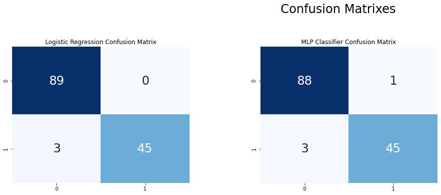

```python
plt.figure(figsize=(24,12))

plt.suptitle("Confusion Matrixes",fontsize=24)
plt.subplots_adjust(wspace = 0.4, hspace= 0.4)


plt.subplot(2,3,1)
plt.title("Logistic Regression Confusion Matrix")
sns.heatmap(cm_lr,annot=True,cmap="Blues",fmt="d",cbar=False, annot_kws={"size": 24})

plt.subplot(2,3,2)
plt.title("MLP Classifier Confusion Matrix")
sns.heatmap(cm_mlp,annot=True,cmap="Blues",fmt="d",cbar=False, annot_kws={"size": 24})
```

# Comparision of Accuracy

[output not shown]

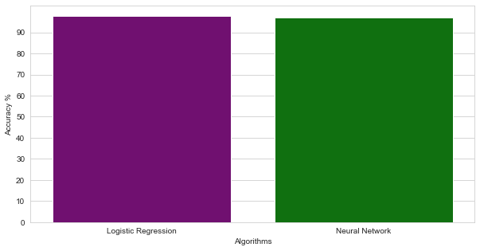

```python
colors = ["purple", "green"]

sns.set_style("whitegrid")
plt.figure(figsize=(10,5))
plt.yticks(np.arange(0,100,10))
plt.ylabel("Accuracy %")
plt.xlabel("Algorithms")
x=["Logistic Regression","Neural Network"]
y=[97.81,97.08]
sns.barplot(x,y, palette=colors)
plt.show()
```

# Performance Improvement :

### 1.Normalizing the Data :

This Scaler removes the median and scales the data according to the quantile range (defaults to IQR: Interquartile Range). The IQR is the range between the 1st quartile (25th quantile) and the 3rd quartile (75th quantile).  
Centering and scaling happen independently on each feature by computing the relevant statistics on the samples in the training set. Median and interquartile range are then stored to be used on later data using the transform method.

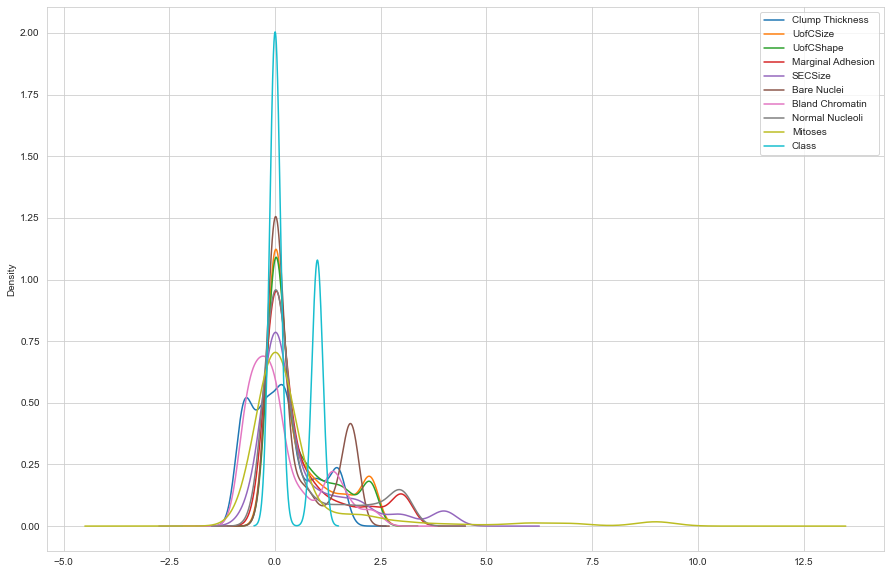

```python
from sklearn.preprocessing import RobustScaler
Rs = RobustScaler(with_scaling=True)
data_tf = Rs.fit_transform(df)
df_a = pd.DataFrame(data_tf,columns=['Clump Thickness', 'UofCSize', 'UofCShape', 'Marginal Adhesion',
       'SECSize', 'Bare Nuclei', 'Bland Chromatin', 'Normal Nucleoli',
       'Mitoses', 'Class'])
df_a.plot.kde(figsize=(15,10))
```

```python
x1= df_a.drop('Class',axis=1).to_numpy()
y1 = df_a['Class'].to_numpy()
from sklearn.model_selection import train_test_split
x_train,x_test,y_train,y_test=train_test_split(x1,y1,test_size=0.2,stratify=y,random_state=100)
```

```python
from sklearn.neural_network import MLPClassifier
mlp = MLPClassifier(hidden_layer_sizes=(9,4,2),
                    activation='relu',solver='adam',
                    max_iter=10000,random_state=100)
mlp.fit(x_train2, y_train)
predictions1 = mlp.predict(x_test2)

from sklearn.metrics import classification_report, confusion_matrix
print(confusion_matrix(y_test,predictions1))
print(classification_report(y_test,predictions1))
```

```
[[88  1]
 [ 3 45]]
              precision    recall  f1-score   support

         0.0       0.97      0.99      0.98        89
         1.0       0.98      0.94      0.96        48

    accuracy                           0.97       137
   macro avg       0.97      0.96      0.97       137
weighted avg       0.97      0.97      0.97       137
```

```python
print(accuracy_score(y_test,predictions1))
```

```
0.9708029197080292
```

### 2.GridSearchCV :

GridSearchCV, It runs through all the different parameters that is fed into the parameter grid and produces the best combination of parameters, based on a scoring metric of your choice (accuracy, f1, etc).  
**estimator:** estimator object being used  
**param_grid:** dictionary that contains all of the parameters to try  
**scoring:** evaluation metric to use when ranking results  
**cv:** cross-validation, the number of cv folds for each combination of parameters

```python
from sklearn.model_selection import GridSearchCV
parameter_space = {
    'hidden_layer_sizes': [(50,50,50), (50,100,50), (100,)],
    'activation': ['tanh', 'relu'],
    'solver': ['sgd', 'adam'],
    'alpha': [0.0001, 0.05],
    'learning_rate': ['constant','adaptive'],
}

clf = GridSearchCV(mlp, parameter_space, n_jobs=-1, cv=3,verbose=2)
clf.fit(x_train2,y_train)
```

```
Fitting 3 folds for each of 48 candidates, totalling 144 fits
```

```
[Parallel(n_jobs=-1)]: Using backend LokyBackend with 8 concurrent workers.
[Parallel(n_jobs=-1)]: Done  25 tasks      | elapsed:    5.3s
[Parallel(n_jobs=-1)]: Done 144 out of 144 | elapsed:   35.9s finished
```

[output not shown]

```python
grid_predictions = clf.predict(x_test2)
print(confusion_matrix(y_test,grid_predictions))
print(classification_report(y_test,grid_predictions))
```

```
[[88  1]
 [ 1 47]]
              precision    recall  f1-score   support

         0.0       0.99      0.99      0.99        89
         1.0       0.98      0.98      0.98        48

    accuracy                           0.99       137
   macro avg       0.98      0.98      0.98       137
weighted avg       0.99      0.99      0.99       137
```

```python
print(accuracy_score(y_test,grid_predictions))
```

```
0.9854014598540146
```

# 3.Principal Component Analysis:

Principal Component Analysis is a Dimensionality reduction Technique. Principal component analysis is a statistical technique that is used to analyze the interrelationships among a large number of variables and to explain these variables in terms of a smaller number of variables, called principal components, with a minimum loss of information.

```python
from sklearn.decomposition import PCA
sklearn_pca = PCA(n_components=0.95)
sklearn_pca.fit(x_train2)
X_train_transformed = sklearn_pca.transform(x_train2)
print(X_train_transformed.shape)
print(x_test.shape)
X_test_transformed =sklearn_pca.transform(x_test2)
print(X_test_transformed.shape)
```

```
(546, 7)
(137, 9)
(137, 7)
```

```python
from sklearn.neural_network import MLPClassifier
mlp = MLPClassifier(hidden_layer_sizes=(9,4,2),
                    activation='relu',solver='adam',
                    max_iter=10000,random_state=100)
mlp.fit(X_train_transformed, y_train)
predictionsPCA = mlp.predict(X_test_transformed)

from sklearn.metrics import classification_report, confusion_matrix
print(confusion_matrix(y_test,predictionsPCA))
print(classification_report(y_test,predictionsPCA))
```

```
[[87  2]
 [ 1 47]]
              precision    recall  f1-score   support

         0.0       0.99      0.98      0.98        89
         1.0       0.96      0.98      0.97        48

    accuracy                           0.98       137
   macro avg       0.97      0.98      0.98       137
weighted avg       0.98      0.98      0.98       137
```

```python
print(accuracy_score(y_test,predictionsPCA))
```

```
0.9781021897810219
```

# Comparision of All Accuracy %

[output not shown]

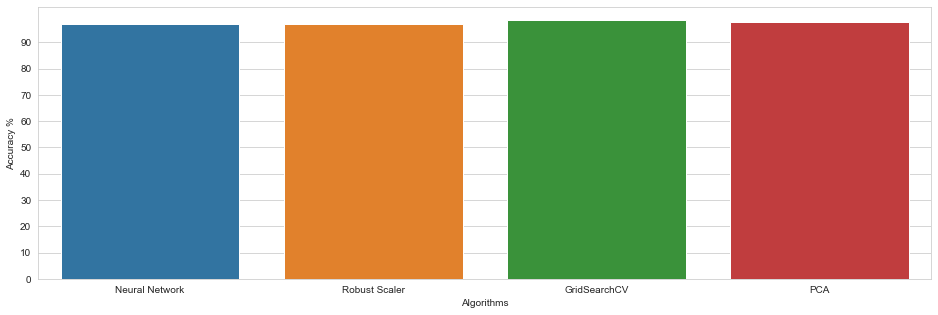

```python
colors = ["purple", "green", "orange", "magenta"]

sns.set_style("whitegrid")
plt.figure(figsize=(16,5))
plt.yticks(np.arange(0,100,10))
plt.ylabel("Accuracy %")
plt.xlabel("Algorithms")
x=["Neural Network","Robust Scaler","GridSearchCV","PCA"]
Y=[97.08,97.08,98.54,97.81]
sns.barplot(x,Y)
plt.show()
```

# Comparision of All Confusion Matrixes

```python
nn1=confusion_matrix(y_test,predictions1)
nn2=confusion_matrix(y_test,grid_predictions)
nn3=confusion_matrix(y_test,predictionsPCA)
```

[figure not shown]

```python
plt.figure(figsize=(24,12))

plt.suptitle("Confusion Matrixes",fontsize=24)
plt.subplots_adjust(wspace = 0.4, hspace= 0.4)

plt.subplot(2,3,1)
plt.title("Neural Network Confusion Matrix")
sns.heatmap(cm_lr,annot=True,cmap="Blues",fmt="d",cbar=False, annot_kws={"size": 24})

plt.subplot(2,3,2)
plt.title("Neural Network with Robust Scaler Confusion Matrix")
sns.heatmap(nn1,annot=True,cmap="Blues",fmt="d",cbar=False, annot_kws={"size": 24})

plt.subplot(2,3,3)
plt.title("Neural Network with GridSearchCV Confusion Matrix")
sns.heatmap(nn2,annot=True,cmap="Blues",fmt="d",cbar=False, annot_kws={"size": 24})

plt.subplot(2,3,4)
plt.title("Neural Network with GridSearchCV PCA Confusion Matrix")
sns.heatmap(nn3,annot=True,cmap="Blues",fmt="d",cbar=False, annot_kws={"size": 24})


plt.show()
```